# Final Project

May 1, 2016

## Data Processing

- Data cleaning - Selection
- Data Analysis
- Model Creating
- Model Evaluation
- Model validation

## Data Cleaning - Selection

- Size

```
## [1] 141966    134
```

- There are a lot of NAs

```
## [1] 5388299
```

- And no complete cases

```
## [1] 0
```

## Data Cleaning - Selection

1. Remove all "unecessary"" variables
   - Not intended to be used for the analysis
   - Supporting variables - those which only provide aditional information/replacement information about other variables
2. Remove all "doubt" cases - observations with doubt value is 0
3. Combine the wounded and killed as "casulaties"
4. Clean all observations with no known location
5. And at this point, seperate the data set into analysis and visualization
6. Combine date/month/year into a date object
7. And finally, rename the variables (because the old names are too terrible)

## And walla, the result…

- Dimension

```
## [1] 59094    21
```

- complete cases

```
## [1] 51494
```

## Data Analysis

- Casualties
- Attack types
- Target types
- General location - Regions
- Specific location - Countries
- Terrorist groups

## Number of casulaties each year 1970 -2014

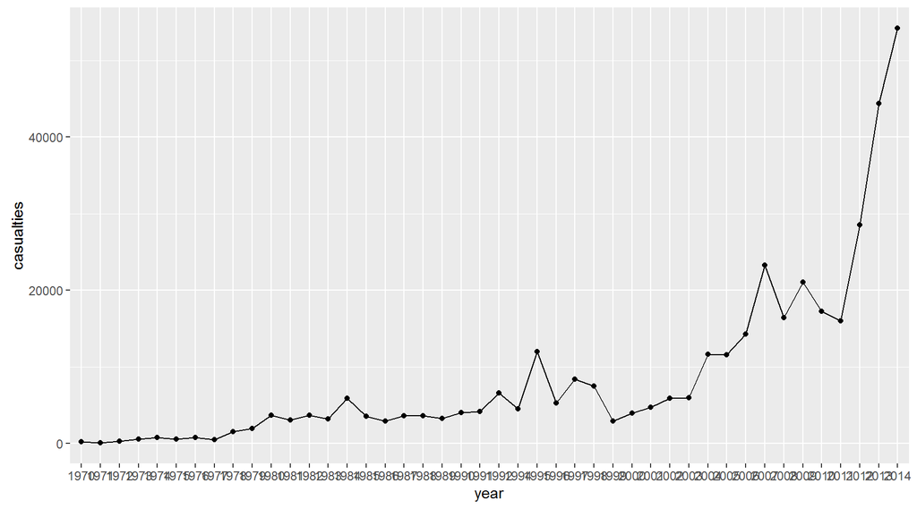

## Type of attack from 1970 - 2014

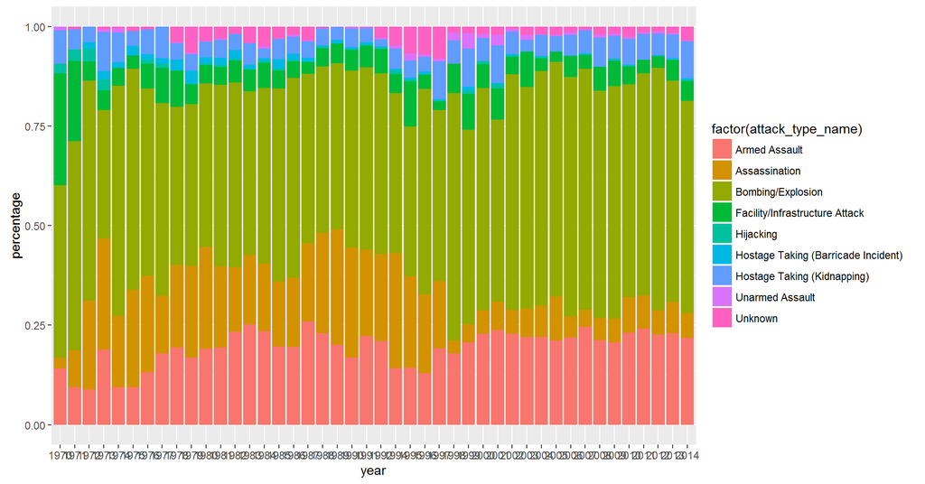

## Type of target from 1970 - 2014

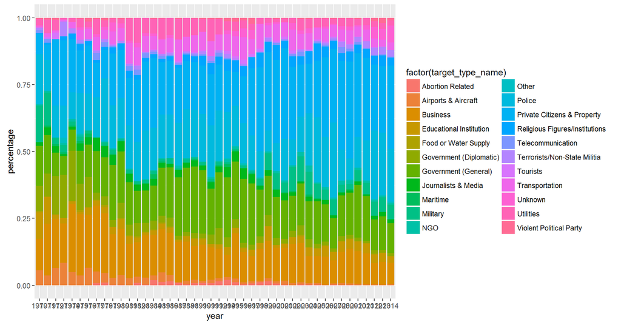

## Location in term of regions o1970 -2014

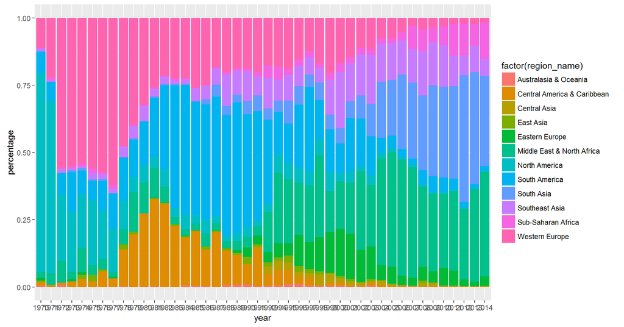

## Countries with most attacks 1970 - 2014

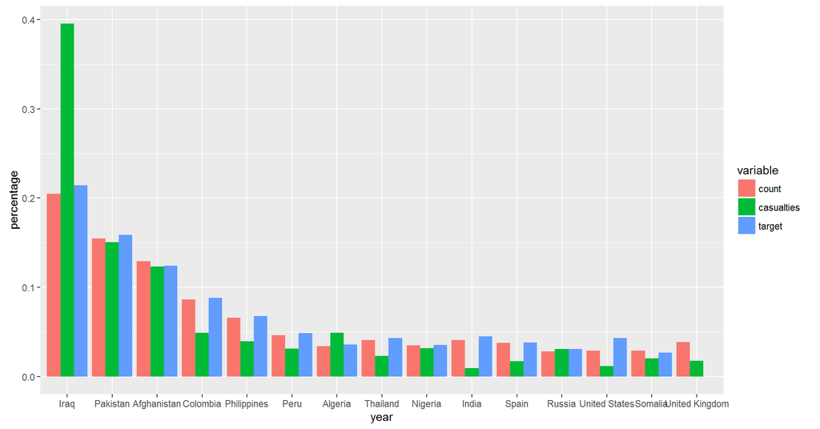

## Most dangerous groups

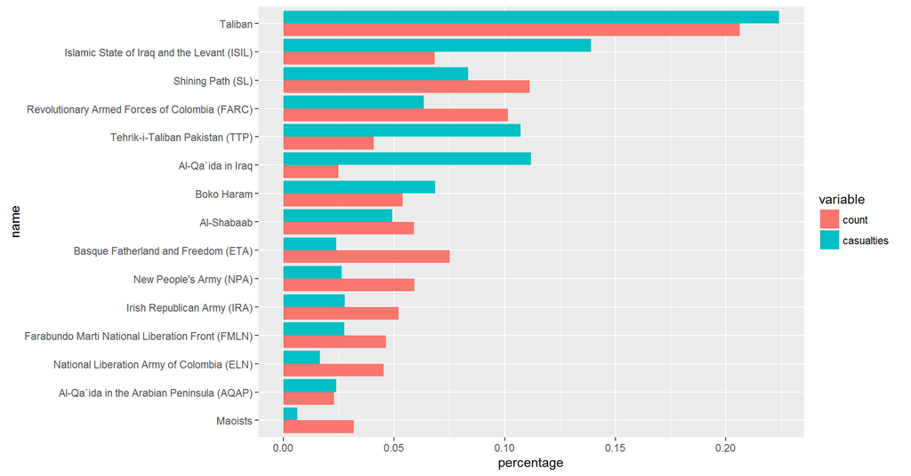

## Data Modelling

1. Predict the terrorist group based on
   - Region
   - Attack type
   - Target type
   - Weapon type
   - Casualties
2. Naive Bayes

## Data Modelling

- Additional data cleaning
- Model construction
- Model evaluation

## Data Modelling - Additional cleaning

- Get the top 15 terror groups
- Convert casualties to categorical variables

## Data Modelling - Model Construction

```r
# Create a model using NaiveBayes
nbc <- NaiveBayes(top_group_name ~ region_name +
                    attack_type_name +
                    target_type_name +
                    weapon_type_name +
                    cas.cat,
                  data = terror.small,
                  fL = 1)

pred.nbc = predict(nbc, terror.test)
```

## Data Modelling - Model Construction

```
##                               row.names.confMat..i. prec  rec   f1
## 1                                 Al-Qa`ida in Iraq 0.52 0.10 0.17
## 2         Al-Qa`ida in the Arabian Peninsula (AQAP) 0.45 0.54 0.49
## 3                                        Al-Shabaab 0.73 0.74 0.73
## 4               Basque Fatherland and Freedom (ETA) 0.68 0.95 0.79
## 5                                        Boko Haram 0.65 0.63 0.64
## 6  Farabundo Marti National Liberation Front (FMLN) 1.00 1.00 1.00
## 7                       Irish Republican Army (IRA) 0.62 0.15 0.24
## 8       Islamic State of Iraq and the Levant (ISIL) 0.69 0.86 0.77
## 9                                           Maoists 0.36 0.21 0.27
## 10       National Liberation Army of Colombia (ELN) 0.37 0.39 0.38
## 11                          New People's Army (NPA) 1.00 0.99 0.99
## 12                                            Other  NaN  NaN  NaN
## 13    Revolutionary Armed Forces of Colombia (FARC) 0.54 0.48 0.51
## 14                                Shining Path (SL) 0.61 0.67 0.64
## 15                                          Taliban 0.76 0.94 0.84
## 16                  Tehrik-i-Taliban Pakistan (TTP) 0.65 0.11 0.19
```

```
##                                                   actual
## predicted                                          Al-Qa`ida in Iraq
##   Al-Qa`ida in Iraq                                               11
##   Al-Qa`ida in the Arabian Peninsula (AQAP)                       20
##   Al-Shabaab                                                       0
##   Basque Fatherland and Freedom (ETA)                              0
##   Boko Haram                                                       0
##   Farabundo Marti National Liberation Front (FMLN)                 0
##   Irish Republican Army (IRA)                                      0
##   Islamic State of Iraq and the Levant (ISIL)                     80
##   Maoists                                                          0
##   National Liberation Army of Colombia (ELN)                       0
##   New People's Army (NPA)                                          0
##   Other                                                            0
##   Revolutionary Armed Forces of Colombia (FARC)                    0
##   Shining Path (SL)                                                0
##   Taliban                                                          0
##   Tehrik-i-Taliban Pakistan (TTP)                                  0
##                                                   actual
## predicted                                          Al-Qa`ida in the Arabian Peninsula (AQAP)
##   Al-Qa`ida in Iraq                                                                        3
##   Al-Qa`ida in the Arabian Peninsula (AQAP)                                               47
##   Al-Shabaab                                                                               0
##   Basque Fatherland and Freedom (ETA)                                                      1
##   Boko Haram                                                                               0
##   Farabundo Marti National Liberation Front (FMLN)                                         0
##   Irish Republican Army (IRA)                                                              0
##   Islamic State of Iraq and the Levant (ISIL)                                             36
##   Maoists                                                                                  0
##   National Liberation Army of Colombia (ELN)                                               0
##   New People's Army (NPA)                                                                  0
##   Other                                                                                    0
##   Revolutionary Armed Forces of Colombia (FARC)                                            0
##   Shining Path (SL)                                                                        0
##   Taliban                                                                                  0
##   Tehrik-i-Taliban Pakistan (TTP)                                                          0
##                                                   actual
## predicted                                          Al-Shabaab
##   Al-Qa`ida in Iraq                                         0
##   Al-Qa`ida in the Arabian Peninsula (AQAP)                 0
```

[output cut: 233 more lines]

```
##   Al-Qa`ida in the Arabian Peninsula (AQAP)                                      0
##   Al-Shabaab                                                                     0
##   Basque Fatherland and Freedom (ETA)                                            0
##   Boko Haram                                                                     0
##   Farabundo Marti National Liberation Front (FMLN)                               0
##   Irish Republican Army (IRA)                                                    0
##   Islamic State of Iraq and the Levant (ISIL)                                    0
##   Maoists                                                                        6
##   National Liberation Army of Colombia (ELN)                                     0
##   New People's Army (NPA)                                                        0
##   Other                                                                          0
##   Revolutionary Armed Forces of Colombia (FARC)                                  0
##   Shining Path (SL)                                                              0
##   Taliban                                                                      160
##   Tehrik-i-Taliban Pakistan (TTP)                                               20
```

## Data Modelling - Model Evaluation

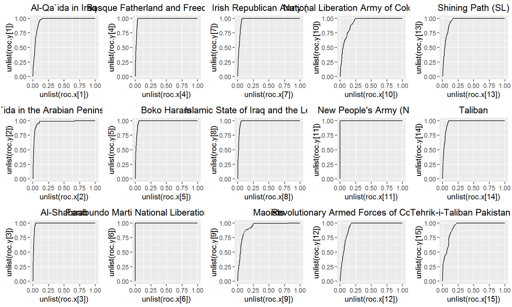

## Model Evaluation - AUCs

```
## [1] "Auc for  Al-Qa`ida in Iraq  is:  0.961461203737208"
## [1] "Auc for  Al-Qa`ida in the Arabian Peninsula (AQAP)  is:  0.97384233932164"
## [1] "Auc for  Al-Shabaab  is:  0.98873039008222"
## [1] "Auc for  Basque Fatherland and Freedom (ETA)  is:  0.986748686329229"
## [1] "Auc for  Boko Haram  is:  0.9849773350905"
## [1] "Auc for  Farabundo Marti National Liberation Front (FMLN)  is:  1"
## [1] "Auc for  Irish Republican Army (IRA)  is:  0.975874001403009"
## [1] "Auc for  Islamic State of Iraq and the Levant (ISIL)  is:  0.984979595850337"
## [1] "Auc for  Maoists  is:  0.934342127953094"
## [1] "Auc for  National Liberation Army of Colombia (ELN)  is:  0.925956876676663"
## [1] "Auc for  New People's Army (NPA)  is:  0.999985685744842"
## [1] "Auc for  Revolutionary Armed Forces of Colombia (FARC)  is:  0.936766189041264"
## [1] "Auc for  Shining Path (SL)  is:  0.951717217443791"
## [1] "Auc for  Taliban  is:  0.970853678813188"
## [1] "Auc for  Tehrik-i-Taliban Pakistan (TTP)  is:  0.931971392034147"
```

## Visualization

# 1970